# Introduction to Generalized Additive Models (GAM) in R

## List of topics

1. Motivation: Why not just use standard methods?
2. Generalized Additive Model (GAM) formula and fit
3. Example: GAM with single predictor
4. Example: GAM with multiple predictors
5. Example: GAM with non-Gaussian outcome
6. Example: Model selection – when to use smooth term?

## Motivating example

```r
dat
```

```
# A tibble: 500 x 4
         y     x1     x2    x3
     <dbl>  <dbl>  <dbl> <int>
 1 -0.424  0.288  0.354      0
 2  1.32   0.788  0.366      1
 3 -0.186  0.409  0.287      0
 4  0.666  0.883  0.0800     1
 5  0.181  0.940  0.365      1
 6  0.491  0.0456 0.178      0
 7  2.82   0.528  0.536      1
 8  0.0930 0.892  0.504      0
 9  1.09   0.551  0.945      0
10  0.939  0.457  0.341      0
# … with 490 more rows
```

## Fit linear regression model

```r
fit <- lm(y ~ x1 + x2 + x3)
summary(fit)
```

```
Call:
lm(formula = y ~ x1 + x2 + x3)

Residuals:
     Min       1Q   Median       3Q      Max
-1.74114 -0.75251  0.00348  0.66608  2.58693

Coefficients:
            Estimate Std. Error t value Pr(>|t|)
(Intercept) -0.28941    0.11013  -2.628  0.00886 **
x1           0.80390    0.13868   5.797 1.20e-08 ***
x2           0.40289    0.13567   2.970  0.00312 **
x3           0.49859    0.07876   6.330 5.48e-10 ***
---
Signif. codes:  0 '***' 0.001 '**' 0.01 '*' 0.05 '.' 0.1 ' ' 1

Residual standard error: 0.8804 on 496 degrees of freedom
Multiple R-squared:  0.1437,    Adjusted R-squared:  0.1385
F-statistic: 27.74 on 3 and 496 DF,  p-value: < 2.2e-16
```

## Run simple model diagnostics

- Check *linearity* of the data assumption with Residuals vs Fitted plot (residual plot will show no fitted pattern)
- Check *normality of residuals* assumption with the QQ plot (should approximately follow a straight line)
- Check *homogeneity* of variance assumption with the Scale-Location plot (residuals should be spread equally along the ranges of predictors)
- Check for *outliers and high levarage points* (high predictor values points) with the Residuals vs Leverage plot

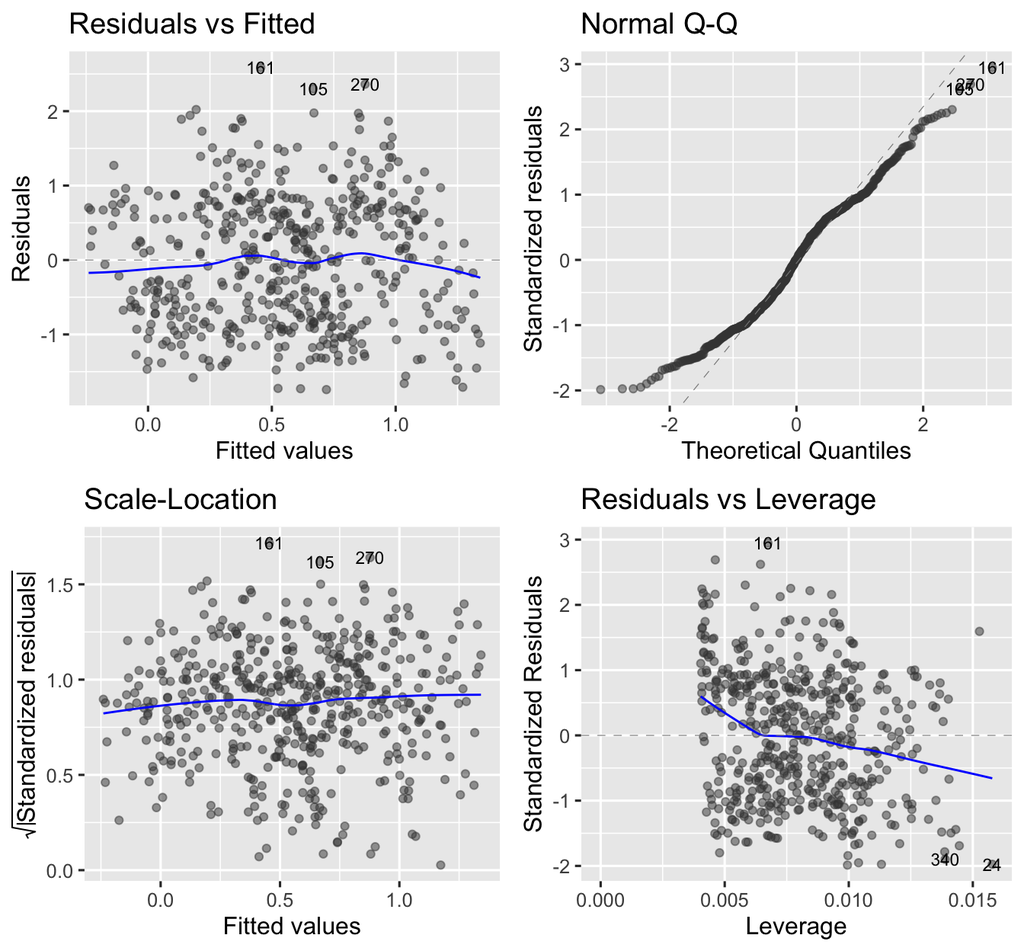

```r
library(ggfortify) # to use autoplot
library(tidyverse)
autoplot(fit, label.size = 3, alpha = 0.5) +
  theme_grey(base_size = 12)
```

## Dig more into checking *linearity* of the data assumption

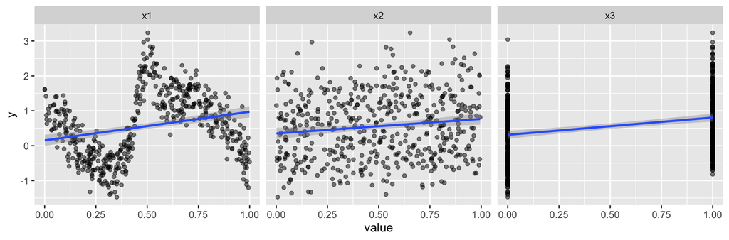

```r
dat %>%
  pivot_longer(cols = -y) %>%
  ggplot(aes(x = value, y = y)) +
  geom_point(alpha = 0.5) +
  geom_smooth(method = "lm") +
  facet_wrap(~ name, nrow = 1) +
  theme_gray(base_size = 12)
```

## Dig more into checking *linearity* of the data assumption

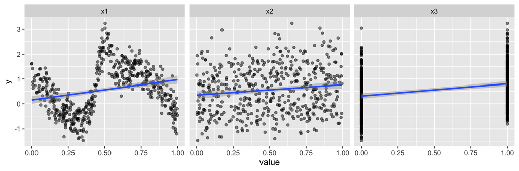

```r
dat %>%
  pivot_longer(cols = -y) %>%
  ggplot(aes(x = value, y = y)) +
  geom_point(alpha = 0.5) +
  geom_smooth(method = "lm") +
  facet_wrap(~ name, nrow = 1) +
  theme_gray(base_size = 12)
```

Ops! Standard LM is not going to capture relationship between `y` and `x1` well.

## Idea: polynomial regression

- We could try a polynomial regression, e.g. fitting a quadratic or cubic function of `x1` within the LM regression framework

```r
# fit_poly3 <- lm(y ~ x1 + I(x1^2) + I(x1^3), data = dat)
fit_poly3 <- lm(y ~ poly(x1, 3), data = dat)
```

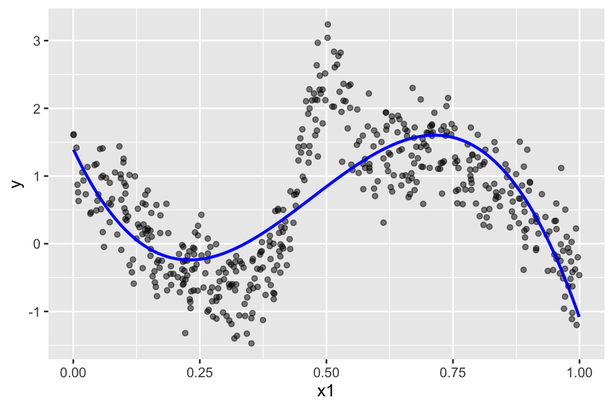

## Idea: polynomial regression

- We could try even higher degrees of a polynomial
- Not really working (low polynomial: poor fit; high polynomial: too wiggly where it doesn’t seem it should)

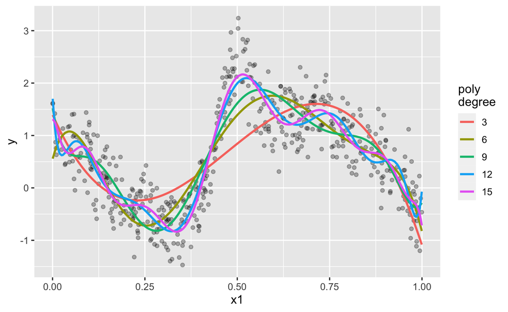

## Idea: piece-wise polynomial regression

- Use a polynomial regression equation in a way that the coefficients are allowed to differ in different parts of the range of predictor

\[ y_{i}=\left\{\begin{array}{ll} \beta_{01}+\beta_{11} x_{i}+\beta_{21} x_{i}^{2}+\beta_{31} x_{i}^{3}+\epsilon_{i} & \text { if } x_{i}<c \\ \beta_{02}+\beta_{12} x_{i}+\beta_{22} x_{i}^{2}+\beta_{32} x_{i}^{3}+\epsilon_{i} & \text { if } x_{i} \geq c \end{array}\right. \]

- Multiple points can be used to divide the data

```r
fit_poly3 <- lm(y ~ poly(x1, 3), data = dat)

library(segmented)
# psi -- starting values for the breakpoints to be estimated
fit_poly3_seg <- segmented(fit_poly3, psi = c(0.2, 0.4, 0.6, 0.8))
```

## Idea: piece-wise polynomial regression

- Not really working (pieces are disconnected or/and are wiggly)

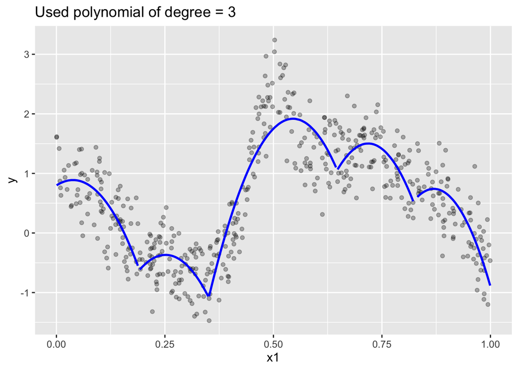

## Idea: piece-wise polynomial regression

- Not really working (pieces are disconnected or/and are wiggly)

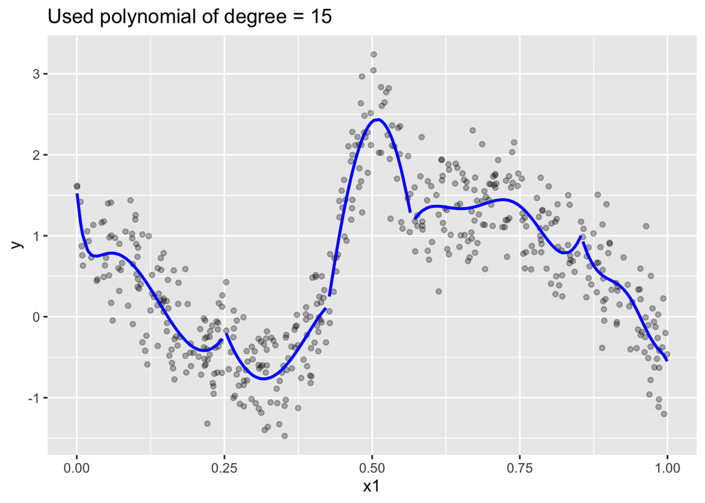

## Credit

- Motivating example (idea and code to generate the data) follows (Clark, 2019)

## References

- (Harezlak et al., 2018) Harezlak, J., Wand, M. P., Ruppert, D. (2018) Semiparametric Regression with R. Springer, New York, NY
- (Wood, 2006) Wood, S. N. Generalized Additive Models: An Introduction with R. (2006) Vol. 66. CRC Press.
- (Ross, 2021) Ross, N. Generalized Additive Models in R. (Accessed online 2021-07-14) URL: https://noamross.github.io/gams-in-r-course/
- (Clark, 2019) Clark, M. Generalized Additive Models. (Accessed online 2021-07-14) URL: https://m-clark.github.io/generalized-additive-models/